# 第8回 遺伝子発現データで、教師あり解析を一周する

## 前回からの接続

第2回から第7回までで、教師あり学習（答えの列がある解析）の道具がそろいました。前処理をする、式を作る、交差検証で評価する、正則化（regularization）で係数を落ち着かせる、前処理とモデルを1本のパイプライン（pipeline）にする、結果を解釈する。

今日は、新しいデータで、この道具を最初から最後まで一周します。データは、遺伝子の発現量です。手がかりの列が、行の数よりずっと多いデータです。これまでの道具を、そのまま使えるでしょうか。

## 今日の分析目標

あなたは眼科の研究者です。ほかの遺伝子の発現量から、TRIM32という遺伝子の発現量を当てられるか。当てられたとして、一緒に動く遺伝子を特定できるかに答える。

ラット120匹の目の組織で測った、31,000本ほどの遺伝子の発現量を使います。手がかりが匹数よりずっと多いときに、当たりを正しく評価する方法と、その落とし穴を確かめます。

もう1つのねらいは、自分のコードを、関数に分けた1本のスクリプトにまとめられるようになることです。最後の「目標に答えられたか」で振り返りましょう。

### 場面

あなたは、目の病気を研究する眼科の研究者です。TRIM32は、網膜の病気（バルデー・ビードル症候群）の原因遺伝子の1つとして報告された遺伝子です（Chiangほか, 2006）。

遺伝子は、ばらばらに働くのではなく、いくつもが一緒に強まったり弱まったりします。TRIM32と一緒に動く遺伝子が分かれば、TRIM32がどんな働きの仲間なのかを考える手がかりになります。

### 手元のデータ

米国アイオワ大学のグループが、交配したラット120匹の目の組織で、遺伝子の発現量を測ったデータです（Scheetzほか, 2006。NCBI GEOのGSE5680）。

1行が1匹です。列は、プローブ（遺伝子の断片を測るための印）ごとの発現量で、31,098本あります。値は、発現量を2を底とする対数（log2）にしたもので、1大きいと発現量が2倍です。TRIM32のプローブだけを、先頭の列`TRIM32`に出してあります。

プローブと遺伝子の名前の対応は、別の表（`rat_eye_genes.csv`）にあります。遺伝子の名前が分かっているプローブは、7割ほどです。

### 最後に出す答え

ほかの遺伝子からTRIM32を当てる式と、その当たり（平均でどれだけ外れるか）です。そして、その式からTRIM32と一緒に動く遺伝子について、何が言えて、何が言えないかです。

## 学習ゴール

この回を終えると、次のことができるようになります。

- 手がかりの列が行より多いデータ（p > n）で、普通の線形回帰（linear regression）の訓練の当たりが当てにならない理由を説明できる
- 答えを見ずに、使わない列を決められる（対照のプローブ、発現の低いプローブ）
- 正則化や列の絞り込みをパイプラインの中に入れ、交差検証で当たりを正しく評価できる
- 答えを使って列を先に絞ってから交差検証すると、当たりがよく見えすぎることを、答えを並べ替えたデータで確かめられる
- 階層的クラスタリングで、遺伝子を一緒に動くまとまりに分け、樹形図を読める
- 遺伝子のまとまりを1本の点数にする部品をクラスで書き、パイプラインに入れられる
- 今日のコードを関数に分けた1本のスクリプトにまとめ、引数を変えて候補を比べ直せる

## 0. 準備

### 最初に実行する：道具を呼び出す

- 役割：このノートで使う道具（ライブラリ）を呼び出す
- 入力：なし
- 出力：なし（終わるとセルの左に ✓ が付く）

今日は、列を絞る道具`SelectKBest`と`f_regression`、階層的クラスタリングの道具`linkage`・`fcluster`・`dendrogram`（scipyというライブラリにあります）、自分の部品をscikit-learnの部品にする`BaseEstimator`が加わります。

```python
import numpy as np
import pandas as pd
import matplotlib.pyplot as plt
from sklearn.linear_model import LinearRegression, LassoCV
from sklearn.preprocessing import StandardScaler
from sklearn.pipeline import make_pipeline
from sklearn.model_selection import train_test_split, KFold
from sklearn.model_selection import cross_val_score
from sklearn.feature_selection import SelectKBest, f_regression
from sklearn.base import BaseEstimator
from scipy.cluster.hierarchy import linkage, fcluster, dendrogram
```

### 図の日本語を表示できるようにする

- 役割：図の中の日本語が □ にならないようにし、図の大きさと字の大きさをそろえる
- 入力：なし
- 出力：「セットアップ完了」の表示

`try:`から先は、日本語表示の道具が動かなくなったときの保険で、中身は読まなくてかまいません。

```python
# 日本語が図の中で □ になるのを防ぐ
!pip install -q japanize-matplotlib
try:
    import japanize_matplotlib
# japanize が動かなくなったときの保険：同梱フォントを直接登録する
except Exception:
    from importlib.util import find_spec
    from matplotlib import font_manager as fm
    from pathlib import Path
    spec = find_spec('japanize_matplotlib')
    ttf = None
    if spec:
        ttf = next(Path(spec.origin).parent.rglob('*.ttf'), None)
    if ttf:
        fm.fontManager.addfont(str(ttf))
        name = fm.FontProperties(fname=str(ttf)).get_name()
        plt.rcParams['font.family'] = name

plt.rcParams['figure.figsize'] = (9, 5)
plt.rcParams['font.size'] = 13
plt.rcParams['axes.unicode_minus'] = False  # マイナス記号の化けを防ぐ
print('セットアップ完了')
```

```
セットアップ完了
```

### お手本：2つの表を読み込む

- 役割：発現量の表と、プローブと遺伝子の名前の表を読み込み、大きさを見る
- 入力：データの置き場所`DATA_DIR`と、2つのファイル名
- 出力：2つの表の大きさ

発現量の表は、大きいので圧縮してあります（`.csv.gz`）。`read_csv`は、圧縮したファイルもそのまま読めます。`index_col=0`は、1列目（ラットの番号、プローブの番号）を行の名前にする指定です。

```python
# データはこのリポジトリから読み込む
DATA_DIR = ('https://raw.githubusercontent.com/k0heiun0/'
            'applied_exercise_preview/main/shared/data')
df = pd.read_csv(f'{DATA_DIR}/rat_eye_full.csv.gz', index_col=0)
genes = pd.read_csv(f'{DATA_DIR}/rat_eye_genes.csv', index_col=0)
print(df.shape)
print(genes.shape)
```

```
(120, 31099)
(31099, 2)
```

発現量の表は120行 × 31,099列で、120匹のラットに、TRIM32の列と31,098本のプローブの列が並びます。遺伝子の名前の表は、プローブ1本が1行です。

### お手本：答えと手がかりに分け、訓練とテストに分ける

- 役割：TRIM32を答え`y`、残りを手がかり`X`にし、訓練75%・テスト25%に分ける
- 入力：表`df`
- 出力：プローブの本数、訓練とテストの匹数

120匹しかいないので、テストを30匹にします（`test_size=0.25`）。テストは、最後に1回だけ使います。

```python
y = df['TRIM32']
X = df.drop(columns='TRIM32')
X_tr, X_te, y_tr, y_te = train_test_split(
    X, y, test_size=0.25, random_state=0)
print(X.shape[1], '本のプローブ')
print(len(X_tr), len(X_te))
```

```
31098 本のプローブ
90 30
```

手がかりは31,098本のプローブです。訓練90匹、テスト30匹です。

### 分析の地図：今日はここ

データ解析は「① データの理解と目標の設定 → ② 前処理（preprocessing）とデータ解析 → ③ 結果の解釈と目標との整合」の3つのフェーズを回ります。今日は総合演習なので、3つのフェーズを全部通ります。

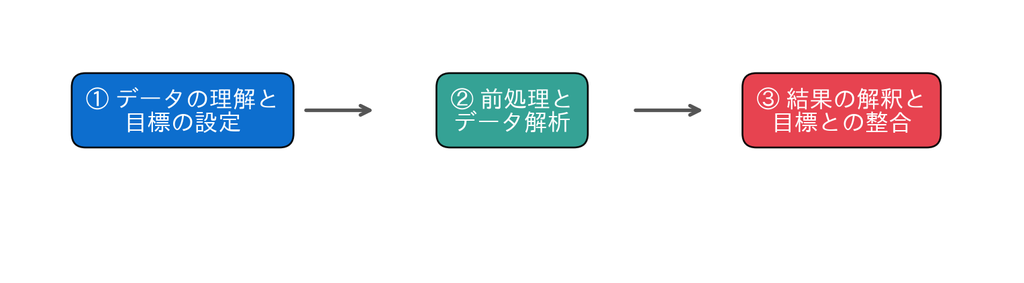

### 今日の道筋

次の8つの小さな問いに答えていきます。

1. どんなデータか？（1節）
2. どの列を使わないか？（2節）
3. 普通の式では？（3節）
4. ラッソなら？（4節）
5. 先に絞ると？（5節）
6. 遺伝子をまとまりに分けると？（6節）
7. どの候補を選ぶか？（7節）
8. 何が言えるか？（8節）

## 1. どんなデータか？

表が読めました。式を作る前に、中身をのぞきます。

### お手本：表の左上をのぞく

- 役割：訓練の先頭3匹・先頭4本のプローブを見る
- 入力：訓練の手がかり`X_tr`
- 出力：表の左上

列の名前の`1367452_at`などが、プローブの番号です。

```python
X_tr.iloc[:3, :4]
```

| sample | 1367452_at | 1367453_at | 1367454_at | 1367455_at |
| --- | --- | --- | --- | --- |
| GSM130572 | 10.6614 | 9.6472 | 9.3595 | 10.8762 |
| GSM130645 | 10.8434 | 9.6382 | 9.3003 | 10.8488 |
| GSM130639 | 10.7260 | 9.5971 | 9.5933 | 10.8887 |

値は5〜11くらいの数です。log2なので、1違うと発現量は2倍違います。

### 変えてみる：答えのTRIM32を見る

- 役割：訓練のTRIM32の平均・標準偏差（standard deviation）・最小・最大を出す
- 入力：訓練の答え`y_tr`
- 出力：要約の数

```python
print(y_tr.describe().round(3))
```

```
count    90.000
mean      8.388
std       0.152
min       7.381
25%       8.323
50%       8.405
75%       8.459
max       8.753
Name: TRIM32, dtype: float64
```

TRIM32の発現量は、平均8.388、標準偏差0.152です。ラットごとの違いは小さく、log2で0.1や0.2の違いを当てることになります。外れの物差しは、これまでと同じ平均絶対誤差（MAE）です。

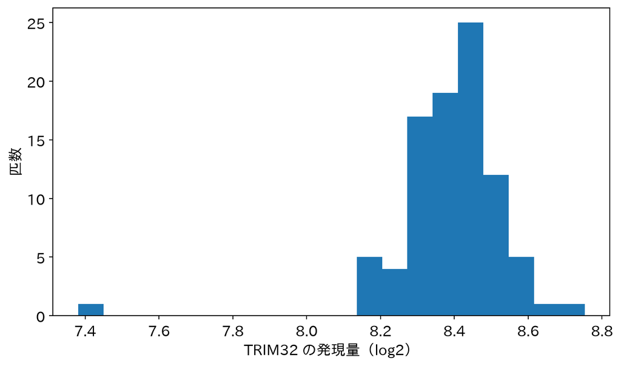

```python
plt.hist(y_tr, bins=20)
plt.xlabel('TRIM32 の発現量（log2）')
plt.ylabel('匹数')
plt.show()
```

### 列が、行よりずっと多い

手がかりは31,098本、訓練は90匹です。手がかりの数を$p$、行の数を$n$と書くと、$p$が$n$の300倍以上あります。このようなデータを、$p > n$（「ピー大なりエヌ」）のデータと呼びます。遺伝子の発現量のデータは、たいていこの形です。

第5回で、30本の手がかりで完全な多重共線性（multicollinearity）に出会いました。今日は、それよりずっと極端な状況です。

```python
print(round(X_tr.shape[1] / X_tr.shape[0], 1))
```

```
345.5
```

$p / n$は、345.5です。

## 2. どの列を使わないか？

手がかりが3万本以上あります。全部を使う前に、第5回で考えた「使わない」の判断をします。ここで大事なのは、答え（TRIM32）を見ずに決めることです。

### お手本：対照のプローブを数える

プローブの中には、遺伝子を測るためではなく、測定がうまくいったかを確かめるための対照のプローブがあります。名前が`AFFX`で始まります。

- 役割：名前が`AFFX`で始まる列を数える
- 入力：手がかりの列の名前`X_tr.columns`
- 出力：対照のプローブの数

`X_tr.columns.str.startswith('AFFX')`は、列の名前1つずつについて、`AFFX`で始まればTrue、そうでなければFalseの並びを返します。`sum()`でTrueを数えるのは、第6回と同じです。

```python
affx = X_tr.columns.str.startswith('AFFX')
print(affx.sum(), '本が対照のプローブ')
```

```
57 本が対照のプローブ
```

57本が対照のプローブです。目の組織の遺伝子ではないので、使いません。

### 変えてみる：対照のプローブを外す

- 役割：対照のプローブ以外の列だけを残す
- 入力：訓練とテストの手がかり、印`affx`
- 出力：残った列の数

`X_tr.loc[:, 条件]`は、条件がTrueの列だけを残します（第1回の行の絞り方を、列に使う形です）。`~`は、TrueとFalseを入れ替えます。

```python
X_tr = X_tr.loc[:, ~affx]
X_te = X_te.loc[:, ~affx]
print(X_tr.shape[1], '本')
```

```
31041 本
```

31,041本になりました。

### 発現の低いプローブ

第5回で、測った値が信頼できない列は使わないほうがよいと学びました。遺伝子発現のデータでは、発現の低いプローブがその例です。発現が低いと、測定の機械が拾う値は、雑音に近くなります。

- 役割：訓練の90匹で、プローブごとの発現量の平均を出し、その分布を見る
- 入力：訓練の手がかり`X_tr`
- 出力：平均の中央値と、平均のヒストグラム

```
5.87
```

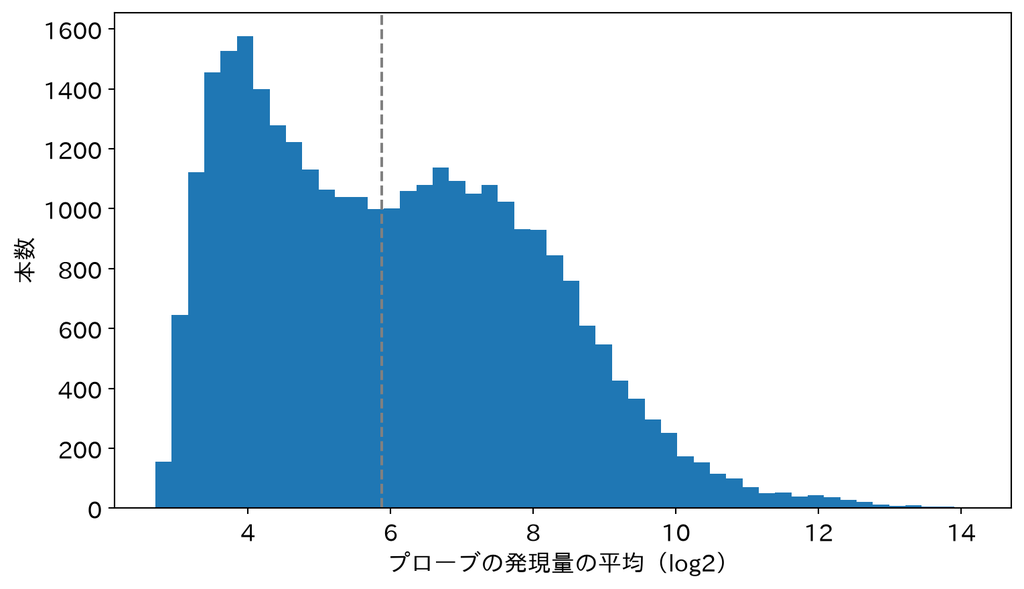

```python
mean_tr = X_tr.mean()                  # プローブごとの平均（訓練）
print(round(mean_tr.median(), 2))
plt.hist(mean_tr, bins=50)
plt.axvline(mean_tr.median(), color='gray', ls='--')
plt.xlabel('プローブの発現量の平均（log2）')
plt.ylabel('本数')
plt.show()
```

プローブの平均は、低いほう（3〜5）にも山があります。発現の平均の中央値は5.87です。ここでは、平均が中央値以下の半分を、発現の低いプローブとして使わないことにします。中央値で切るのは、決め方の1つにすぎません。決めた基準は、報告に書き残します。

### TODO①：残る列を数える

`mean_tr > mean_tr.median()`で、平均が中央値より大きい列の印`keep`を作り、Trueの数（残る列の数）と、Falseの数（外す列の数）を表示してください。

```python
# TODO: 平均が中央値より大きい列の印 keep を作り、残す数・外す数を出す
# ヒント: keep = mean_tr > mean_tr.median()
#         keep.sum() と (~keep).sum()
...;
```

残るのは15,520本、外すのは15,521本です。中央値で切ったので、ほぼ半分ずつになります。

### お手本：発現の低いプローブを外す

- 役割：印`keep`がTrueの列だけを、訓練とテストに残す
- 入力：訓練とテストの手がかり、平均`mean_tr`
- 出力：残った訓練の表の大きさ

```python
keep = mean_tr > mean_tr.median()
X_tr = X_tr.loc[:, keep]
X_te = X_te.loc[:, keep]
print(X_tr.shape)
```

```
(90, 15520)
```

訓練は90匹 × 15,520本になりました。対照のプローブと発現の低い半分を外しました。

ここまで、答えのTRIM32は一度も使っていません。平均は訓練の90匹だけで計算しました（第3回の「訓練だけで決める」）。

なお、試してみると、発現の低い半分を外しても、あとで作る式の当たりはほとんど変わりません。外す理由は、当たりのためではなく、計算を軽くし、雑音に近い列を「効いている遺伝子」として読んでしまわないためです。

## 3. 普通の式では？

使う列が15,520本に決まりました。まずは、これまでの普通の線形回帰で当ててみます。比べる相手として、全員を訓練の平均で当てたときのMAEも出します。

### お手本：普通の線形回帰で当てる

- 役割：15,520本で線形回帰の式を作り、訓練とテストのMAEを出す。平均で当てたときのテストのMAEも出す
- 入力：訓練とテストの手がかりと答え
- 出力：訓練のMAE、テストのMAE、平均で当てたときのテストのMAE

```python
def mae(y, pred):
    return np.abs(y - pred).mean()

ols = LinearRegression().fit(X_tr, y_tr)
print(round(mae(y_tr, ols.predict(X_tr)), 4))     # 訓練
print(round(mae(y_te, ols.predict(X_te)), 4))     # テスト
print(round(mae(y_te, y_tr.mean()), 4))           # 平均で当てると
```

```
0.0
0.0787
0.0913
```

訓練のMAEは0です。90匹の全員を、ぴったり当てました。ところが、テストのMAEは0.0787で、平均で当てたときの0.0913と比べて、少しよいだけです。

### なぜ訓練でぴったり当たるのか

式を作るのは、係数を決めることでした。係数は、15,520本の列それぞれに1つと、切片で、15,521個あります。一方、当てる相手は90匹です。

未知数が15,521個で、式が90本の連立方程式を考えます。未知数のほうがずっと多いので、90匹全員をぴったり当てる係数は、無数にあります。訓練でぴったり当たるのは、式がよいからではなく、自由度（degrees of freedom）が多すぎるからです。訓練の当たりは、まったく当てになりません。

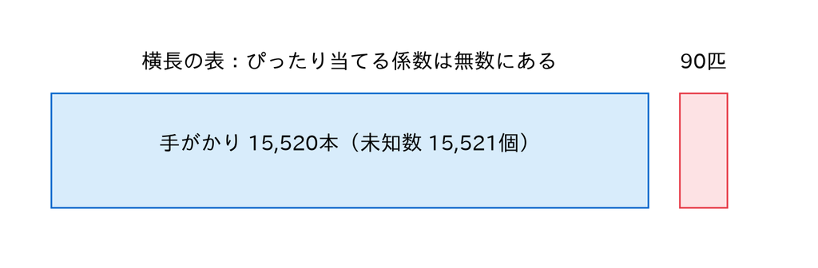

### 交差検証で比べる準備

テストは最後に1回だけ使いたいので、ここからの候補の比較は、訓練の90匹の交差検証で行います（第4回）。比べる相手の、平均で当てたときの交差検証のMAEも出しておきます。

- 役割：訓練の90匹を5つの組に分け、各回で、その回の訓練の平均で当てたときのMAEを出す
- 入力：訓練の答え`y_tr`
- 出力：5回分のMAEと、その平均

```python
kf = KFold(n_splits=5, shuffle=True, random_state=0)
base = []
for tr_i, te_i in kf.split(X_tr):
    base.append(mae(y_tr.iloc[te_i], y_tr.iloc[tr_i].mean()))
print(np.round(base, 4))
print(round(np.mean(base), 4))
```

```
[0.0794 0.0902 0.0787 0.0948 0.1364]
0.0959
```

平均で当てると、交差検証のMAEは0.0959です。これより小さくできれば、遺伝子の情報が役に立っている、と言えます。

## 4. ラッソなら？

普通の式は、訓練では当たっても、テストではあまり当たりませんでした。係数が自由に動きすぎるからです。第5回では、係数に罰をかけて落ち着かせました。罰が強ければ、ラッソは多くの係数をちょうど0にします。15,520本のうち、本当に使う遺伝子を、ラッソに選ばせてみます。

### おさらい：LassoCVとパイプライン

`LassoCV`は、罰の強さαを、交差検証で自分で選ぶラッソです（第5回の発展）。罰の前に標準化（standardization）するので、`StandardScaler`とつないで1本のパイプラインにします（第7回）。

```python
lasso = make_pipeline(StandardScaler(), LassoCV())
```

### お手本：ラッソのパイプラインを交差検証する

- 役割：標準化と`LassoCV`のパイプラインを作り、訓練の90匹の5つの組で交差検証して、MAEを出す
- 入力：訓練の手がかり`X_tr`と答え`y_tr`、分け方`kf`
- 出力：5回分のMAEと、その平均

`cross_val_score`の符号は、第5回で読んだとおり、マイナスで返ってくるので`-`を付けます。`max_iter=5000`は、収束（convergence）の警告を防ぐために、くり返しの回数を増やす指定です（第5回）。列が多いので、このセルは1分ほどかかります。

```python
lasso = make_pipeline(StandardScaler(),
                      LassoCV(cv=5, random_state=0, max_iter=5000))
scores = -cross_val_score(lasso, X_tr, y_tr, cv=kf,
                          scoring='neg_mean_absolute_error')
print(scores.round(4))
print(round(scores.mean(), 4))
```

```
[0.0876 0.0628 0.0525 0.0776 0.0975]
0.0756
```

交差検証のMAEは0.0756です。平均で当てた0.0959より、2割ほど小さくなりました。遺伝子の情報は、役に立っています。

### 交差検証が2重になっている

このセルでは、交差検証が2つ重なっています。

1. 外側：`cross_val_score`が、90匹を5つの組に分け、1つの組を評価用に取っておく
2. 内側：残りの72匹の中で、`LassoCV`が、さらに5つの組に分けてαを選ぶ

αを選ぶのは、答えを見て決める手順です。それを外側の評価用の組を見ずに行うので、評価用の組は、本当に「まだ見ていない匹」のままです。このように交差検証を重ねる形を、入れ子の交差検証（nested cross-validation）と呼びます。パイプラインに`LassoCV`を入れたので、入れ子は自動でできています。

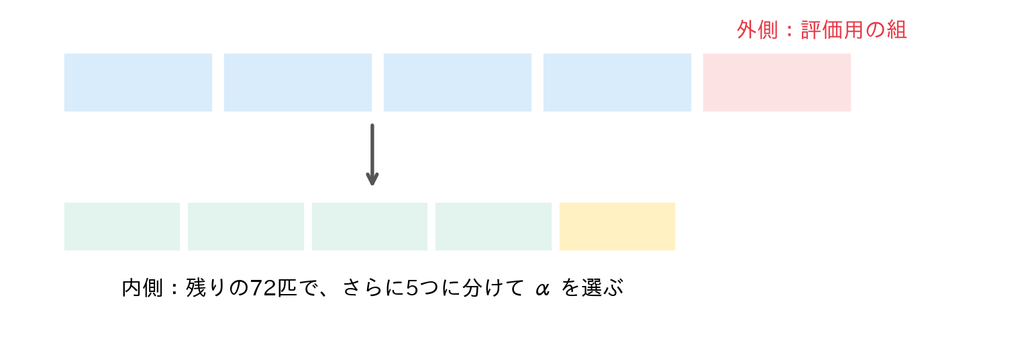

### お手本：訓練の全員で作り直し、選ばれた遺伝子の数を見る

- 役割：訓練の90匹全員でパイプラインを作り直し、選ばれたαと、係数が0でない列の数を出す
- 入力：パイプライン`lasso`、訓練の手がかりと答え
- 出力：αと、0でない係数の数

`lasso[-1]`は、パイプラインの最後の部品（`LassoCV`）です（第7回）。

```python
lasso.fit(X_tr, y_tr)
print(round(lasso[-1].alpha_, 4))
print((lasso[-1].coef_ != 0).sum(), '本が0でない')
```

```
0.0012
87 本が0でない
```

αは0.0012で、係数が0でない列は87本です。15,520本のうち、0.6%ほどしか使っていません。

### TODO②：選ばれた遺伝子の名前を見る

ラッソの係数を、列の名前を付けた`pd.Series`にし、0でない係数のうち、絶対値の大きい5本のプローブと、その遺伝子の名前を表示してください。遺伝子の名前は、表`genes`の`symbol`の列にあります。

```python
# TODO: 係数の絶対値が大きい5本の、係数と遺伝子の名前を表示する
# ヒント: coef = pd.Series(lasso[-1].coef_, index=X_tr.columns)
#         top5 = coef.abs().sort_values(ascending=False).index[:5]
#         genes.loc[top5, 'symbol'] で名前
...;
```

5本のうち、名前のないプローブ（`NaN`）もあります。遺伝子の名前が分かっていても、受講者のみなさんにはなじみのない名前ばかりでしょう。研究の場では、ここから文献を調べ、その遺伝子がどんな働きを持つかを確かめていきます。今日は、選ばれた遺伝子をどこまで信じてよいかを、6節と8節で考えます。

## 5. 先に絞ると？

ラッソは、15,520本から87本を選びました。もっと単純な方法も考えられます。TRIM32と相関の強い遺伝子を、先に数本だけ選び、その数本で普通の線形回帰をする方法です。

### お手本：相関の強い10本を選んで当てる

- 役割：訓練の90匹で、各プローブとTRIM32の相関係数を出し、絶対値の大きい10本を選ぶ。その10本の線形回帰を交差検証する
- 入力：訓練の手がかりと答え
- 出力：選んだ10本の相関係数と、交差検証のMAE

`X_tr.corrwith(y_tr)`は、`X_tr`の列1本ずつについて、`y_tr`との相関係数を出します。

```python
r = X_tr.corrwith(y_tr)                # 各プローブと TRIM32 の相関
top10 = r.abs().sort_values(ascending=False).index[:10]
print(r[top10].round(3).values)
pipe10 = make_pipeline(StandardScaler(), LinearRegression())
scores = -cross_val_score(pipe10, X_tr[top10], y_tr, cv=kf,
                          scoring='neg_mean_absolute_error')
print(round(scores.mean(), 4))
```

```
[ 0.819  0.817  0.807  0.807  0.802 -0.797  0.796  0.794  0.792  0.79 ]
0.057
```

選んだ10本は、どれも相関係数の絶対値が0.79以上です。交差検証のMAEは0.057で、ラッソの0.0756よりずっと小さく見えます。

### 問い：0.057は、本当の当たりか？

10本を選んで普通の線形回帰をしただけで、ラッソよりずっと当たりました。この0.057を、まだ見ていないラットでの当たりとして報告してよいでしょうか。考えを下に書いてください。

（ここに考えを書く）

### 確かめ方：答えを並べ替える

確かめるために、TRIM32の値を、ラットの間でばらばらに並べ替えます。並べ替えると、どの遺伝子とも本当の関係はなくなります。関係のないデータで当たって見えたら、その手順はおかしい、と分かります。

- 役割：答えを並べ替えた`y_shuf`を作り、お手本と同じ手順（相関の強い10本を選んで交差検証）を行う。平均で当てたときのMAEも出す
- 入力：訓練の手がかりと答え
- 出力：並べ替えた答えでの、10本の交差検証のMAEと、平均で当てたときのMAE

`np.random.default_rng(0).permutation(...)`は、並びをばらばらに並べ替えます（`0`は並べ替え方の番号）。

```python
rng = np.random.default_rng(0)
y_shuf = pd.Series(rng.permutation(y_tr.values), index=y_tr.index)
r_s = X_tr.corrwith(y_shuf)
top_s = r_s.abs().sort_values(ascending=False).index[:10]
scores = -cross_val_score(pipe10, X_tr[top_s], y_shuf, cv=kf,
                          scoring='neg_mean_absolute_error')
base_s = []
for tr_i, te_i in kf.split(X_tr):
    base_s.append(mae(y_shuf.iloc[te_i], y_shuf.iloc[tr_i].mean()))
print(round(scores.mean(), 4), round(np.mean(base_s), 4))
```

```
0.0863 0.0954
```

関係のないデータなのに、10本の式の交差検証のMAEは0.0863で、平均で当てた0.0954より小さくなりました。当たって見えるのです。

### なぜ当たって見えるのか

10本を選ぶとき、90匹全員の答えを使いました。その90匹には、交差検証の各回で評価用に取っておく18匹も入っています。つまり、評価用の匹の答えを見て、その匹にたまたま合う遺伝子を選んでいたのです。

15,520本もあれば、本当は関係がなくても、たまたま答えと相関の強い遺伝子が必ず見つかります。それを選んで評価すれば、当たって見えます。第2回のリーク（leakage）、つまり答えの情報が手がかりに漏れ込むことと同じことが、選び方の手順を通して起きています。

### お手本：選ぶ手順を、パイプラインの中に入れる

正しくは、10本を選ぶ手順も、交差検証の各回の中で、その回の訓練の匹だけを使って行います。そのための部品が`SelectKBest`です。

- 役割：標準化 → 相関の強い10本を選ぶ → 線形回帰、のパイプラインを作り、交差検証する
- 入力：訓練の手がかり（15,520本すべて）と答え
- 出力：交差検証のMAE

`SelectKBest(f_regression, k=10)`は、`fit`のときに、渡された匹で、答えとの関係の強さ（`f_regression`）を列ごとに測り、強い10本を覚えます。`transform`では、その10本だけを残します。`f_regression`の強さは、相関係数の絶対値と同じ順に並ぶので、相関の強い10本を選ぶことになります。

```python
sel10 = make_pipeline(StandardScaler(),
                      SelectKBest(f_regression, k=10),
                      LinearRegression())
scores = -cross_val_score(sel10, X_tr, y_tr, cv=kf,
                          scoring='neg_mean_absolute_error')
print(scores.round(4))
print(round(scores.mean(), 4))
```

```
[0.0737 0.0612 0.06   0.0618 0.0856]
0.0685
```

正しく評価すると、交差検証のMAEは0.0685です。先に選んだときの0.057より大きくなりましたが、ラッソの0.0756よりは小さく、平均の0.0959よりずっと小さい値です。相関の強い遺伝子で当てる方法は、正しく評価しても、役に立っています。

### TODO③：並べ替えた答えで、正しく評価する

お手本の`sel10`を、並べ替えた答え`y_shuf`で交差検証し、MAEの平均を表示してください。平均で当てたときの0.0954と比べましょう。

```python
# TODO: sel10 を y_shuf で交差検証し、MAE の平均を表示する
# ヒント: お手本の cross_val_score の y_tr を y_shuf に変える
...;
```

MAEは0.1228で、平均で当てた0.0954より大きくなります。関係のないデータでは、正しく評価すれば、当たらないと分かります。

答えを使う手順（列を選ぶ、αを選ぶ、標準化の平均を決める）は、すべてパイプラインに入れて、交差検証の中で行います。

## 6. 遺伝子をまとまりに分けると？

ここまでの2つの方法は、どちらも答えのTRIM32を使って遺伝子を選びました。今度は逆に、答えを見ずに、遺伝子どうしの動き方だけから、一緒に動く遺伝子のまとまりを探します。まとまりが見つかったら、あとで答えと照らします。

遺伝子をまとまりに分けるのに、階層的クラスタリング（hierarchical clustering）という方法を使います。初めての方法なので、5本の小さな例から始めます。

### お手本：5本の遺伝子の相関を見る

- 役割：5本のプローブを選び、訓練の90匹での相関係数の表を作る
- 入力：5本のプローブの番号`ex`、訓練の手がかり、遺伝子の名前の表
- 出力：5本の遺伝子の名前と、相関係数の表

`.rename(index=..., columns=...)`で、行と列の名前を、プローブの番号から遺伝子の名前に付け替えます。

```python
ex = ['1383110_at', '1394033_at', '1376559_at', '1371242_at',
      '1379101_at']
names = genes.loc[ex, 'symbol']
print(names.values)
corr5 = X_tr[ex].corr().rename(index=names, columns=names)
print(corr5.round(2))
```

```
['Klhl24' 'Rbbp9' 'Rpia' 'Grm8' 'Dhx36']
        Klhl24  Rbbp9  Rpia  Grm8  Dhx36
Klhl24    1.00   0.83 -0.70 -0.62   0.02
Rbbp9     0.83   1.00 -0.69 -0.57  -0.00
Rpia     -0.70  -0.69  1.00  0.90  -0.01
Grm8     -0.62  -0.57  0.90  1.00  -0.06
Dhx36     0.02  -0.00 -0.01 -0.06   1.00
```

Klhl24とRbbp9は相関0.83、RpiaとGrm8は0.90で、それぞれ一緒に動きます。Klhl24とRpiaは−0.70で、逆向きに動きます。Dhx36は、ほかのどれとも相関が0に近く、別の動き方をしています。

### 遺伝子どうしの距離

一緒に動く遺伝子ほど「近い」と考えます。相関係数$r$から、距離$d$を次のように決めます。

$$d = 1 - r$$

一緒に動く（$r = 1$）なら距離0、関係がない（$r = 0$）なら距離1、逆向きに動く（$r = -1$）なら距離2です。

- 役割：5本の遺伝子の距離の表を作る
- 入力：相関係数の表`corr5`
- 出力：距離の表

```python
dist5 = 1 - corr5
print(dist5.round(2))
```

```
        Klhl24  Rbbp9  Rpia  Grm8  Dhx36
Klhl24    0.00   0.17  1.70  1.62   0.98
Rbbp9     0.17   0.00  1.69  1.57   1.00
Rpia      1.70   1.69  0.00  0.10   1.01
Grm8      1.62   1.57  0.10  0.00   1.06
Dhx36     0.98   1.00  1.01  1.06   0.00
```

いちばん近いのは、RpiaとGrm8（0.1）で、次がKlhl24とRbbp9（0.17）です。

### 近いものから、順にまとめる

階層的クラスタリングは、次の手順をくり返します。

1. はじめは、5本の遺伝子が、それぞれ1本ずつのまとまり
2. いちばん近い2つのまとまりを、1つにまとめる
3. まとまりが1つになるまで、2をくり返す

5本の例では、まずRpiaとGrm8（距離0.1）、次にKlhl24とRbbp9（距離0.17）がまとまります。

### まとまりどうしの距離：群平均法

2本がまとまったあとは、まとまりとまとまりの距離が必要です。ここでは、2つのまとまりから1本ずつ選んだ組の距離を、すべて平均したものにします。この決め方を、群平均法（average linkage）と呼びます。

まとまり$A$と$B$の遺伝子の数を$|A|$、$|B|$とすると、

$$D(A, B) = \frac{1}{|A|\,|B|} \sum_{a \in A} \sum_{b \in B} d(a, b)$$

です。Dhx36と、{Klhl24, Rbbp9}の距離は、Dhx36とKlhl24の距離0.98と、Dhx36とRbbp9の距離1.0の平均で、0.99です。Dhx36と{Rpia, Grm8}の距離は、1.01と1.06の平均で、0.99より大きくなります。小さいほう、{Klhl24, Rbbp9}とDhx36が、3番目にまとまります。

### お手本：linkageで、まとめる手順を計算する

- 役割：5本の遺伝子を、群平均法と距離$1 - r$でまとめる手順を計算する
- 入力：訓練の5本の列`X_tr[ex]`
- 出力：まとめた手順の表（1行が1回のまとめ）

`linkage`は、行をまとめていきます。今は遺伝子（列）をまとめたいので、`.T`で表の行と列を入れ替えて（転置して）渡します。`'average'`は群平均法、`metric='correlation'`は距離$1 - r$の指定です。

```python
Z5 = linkage(X_tr[ex].T, 'average', metric='correlation')
print(Z5.round(3))
```

```
[[2.    3.    0.105 2.   ]
 [0.    1.    0.174 2.   ]
 [4.    6.    0.991 3.   ]
 [5.    7.    1.443 5.   ]]
```

1行が1回のまとめで、左から「まとめた2つの番号、そのときの距離、まとまりの遺伝子の数」です。番号の0〜4は、5本の遺伝子（`ex`の順）、5以上は、それまでにできたまとまり（5が1回目、6が2回目…）です。

1回目は2番（Rpia）と3番（Grm8）を距離0.105で、2回目は0番（Klhl24）と1番（Rbbp9）を0.174で、3回目は4番（Dhx36）と6番（2回目のまとまり）を0.991でまとめています。手で計算したとおりです。

### お手本：樹形図に描く

- 役割：まとめた手順を、樹形図に描く
- 入力：手順の表`Z5`と、遺伝子の名前
- 出力：樹形図

まとめた手順を描いた図を、樹形図（dendrogram）と呼びます。縦の高さが、まとめたときの距離です。

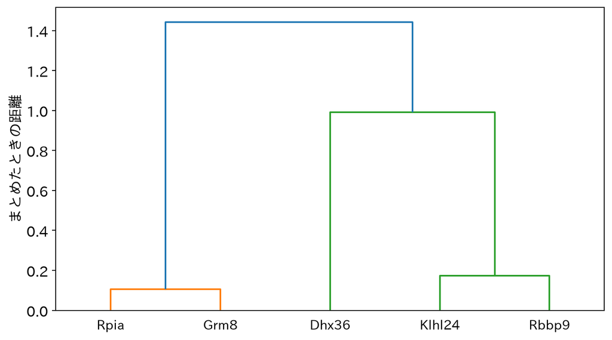

```python
dendrogram(Z5, labels=names.values)
plt.ylabel('まとめたときの距離')
plt.show()
```

低い位置でつながっている遺伝子ほど、一緒に動きます。RpiaとGrm8、Klhl24とRbbp9が、低い位置でまとまっています。

### お手本：いくつのまとまりに切るか

樹形図を、ある高さで横に切ると、その下でつながっている遺伝子が、1つのまとまりになります。`fcluster`は、まとまりの数を決めて切ります。

- 役割：5本の遺伝子を、2つのまとまりに切る
- 入力：手順の表`Z5`
- 出力：遺伝子ごとの、まとまりの番号

`'maxclust'`は、「まとまりの数が2以下になるように切る」という指定です。

```python
print(fcluster(Z5, 2, 'maxclust'))
```

```
[2 2 1 1 2]
```

Klhl24・Rbbp9・Dhx36が1つ、Rpia・Grm8がもう1つのまとまりになりました。これが、階層的クラスタリングの全体です。

### お手本：2,000本を、10のまとまりに分ける

5本の例と同じことを、2,000本で行います。2,000本は、答えを見ずに、訓練の90匹での分散（ばらつき）の大きい順に選びます。ばらつきの小さい遺伝子は、どのラットでもほぼ同じなので、一緒に動いているかを判断しにくいからです。

- 役割：分散の大きい2,000本を、群平均法で10のまとまりに分け、まとまりごとの遺伝子の数を出す
- 入力：訓練の手がかり
- 出力：まとまりごとの遺伝子の数

`pd.Series(…, index=var_top)`で、まとまりの番号に、プローブの番号を付けます。

```python
var_top = X_tr.var().sort_values(ascending=False).index[:2000]
Z = linkage(X_tr[var_top].T, 'average', metric='correlation')
groups = pd.Series(fcluster(Z, 10, 'maxclust'), index=var_top)
print(groups.value_counts().sort_index())
```

```
1       19
2      143
3     1155
4       12
5        9
6      115
7      527
8       10
9        3
10       7
Name: count, dtype: int64
```

10のまとまりの大きさは、1,155本・527本・143本・115本のような大きいものから、3本・7本の小さいものまで、さまざまです。

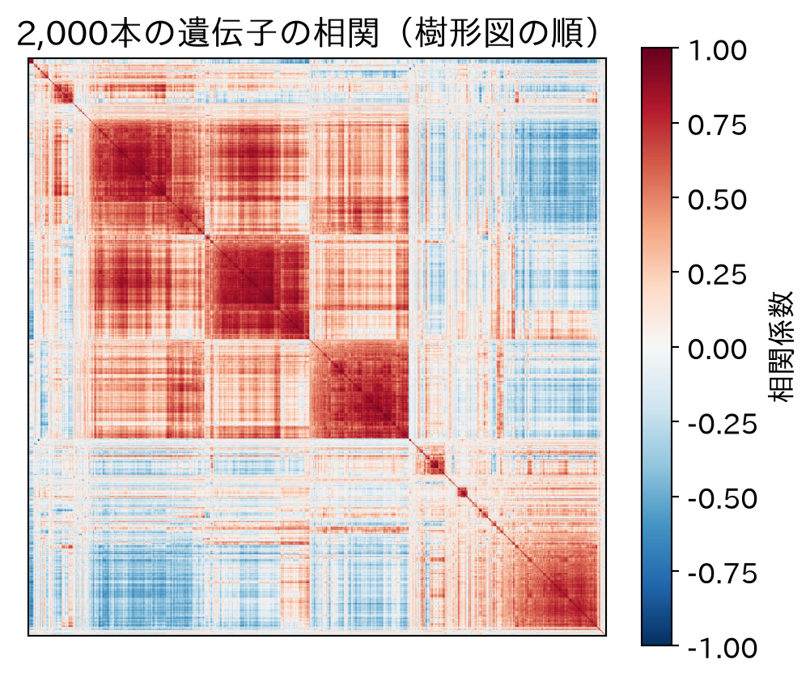

2,000本どうしの相関を、樹形図の順に並べて色で描きました。赤は一緒に動く、青は逆向きに動く組です。対角線に沿って、赤い四角がいくつも見えます。それぞれの四角が、一緒に動く遺伝子のまとまりです。

### お手本：まとまりを1本の点数にし、答えと照らす

まとまりの遺伝子は一緒に動くので、まとめて1本の点数にします。遺伝子を標準化してから、まとまりの中で平均します。

- 役割：2,000本を標準化し、まとまりごとに平均した点数を作り、TRIM32との相関係数を出す
- 入力：訓練の手がかり、まとまりの番号`groups`、答え
- 出力：まとまりごとの、点数とTRIM32の相関係数

ここで、初めて答えのTRIM32を使います。

```python
Zs = (X_tr[var_top] - X_tr[var_top].mean()) / X_tr[var_top].std()
score = pd.DataFrame()
for g in range(1, 11):
    score[g] = Zs.loc[:, groups == g].mean(axis=1)   # g の平均
print(score.corrwith(y_tr).round(3))
```

```
1    -0.664
2    -0.134
3     0.024
4     0.033
5     0.284
6     0.294
7     0.746
8     0.072
9     0.168
10    0.041
dtype: float64
```

7番のまとまり（527本）の点数は、TRIM32と相関0.746で、一緒に強く動きます。1番のまとまり（19本）は−0.664で、逆向きに動きます。ほかのまとまりは、0.3以下です。答えを見ずに分けたまとまりの中に、TRIM32と一緒に動くまとまりが見つかりました。

### 平均すると、相関が強くなる

7番のまとまりの遺伝子を1本ずつ見ると、TRIM32との相関は、それほど強くありません。

- 役割：7番のまとまりの遺伝子1本ずつの、TRIM32との相関係数の中央値を出す
- 入力：訓練の手がかり、`groups`、答え
- 出力：相関係数の中央値

```python
r7 = X_tr[var_top].corrwith(y_tr)[groups == 7]
print(round(r7.median(), 3))
```

```
0.469
```

1本ずつでは、相関の中央値は0.469です。それが、527本を平均すると0.746になりました。1本ずつの測定には雑音がありますが、一緒に動く遺伝子を平均すると、雑音が打ち消し合い、共通の動きが残るのです。

### お手本：まとまりの点数を作る部品

まとまりを作る手順も、パイプラインに入れたい部品です。今回は答えを使いませんが、分散や平均を訓練で決めるので、交差検証の各回の中で行うのが正しい手順です。第7回の`Standardizer`と同じ形で、クラスにします。

- 役割：`fit`で、分散の大きい遺伝子を選び、まとまりに分け、平均と標準偏差を覚える。`transform`で、覚えた値で標準化し、まとまりごとの点数の表を返す
- 入力：なし（部品の設計図を書くだけ）
- 出力：なし

新しいのは2つです。1つ目の`__init__`は、部品を作るときに引数（遺伝子の数`n_genes`、まとまりの数`k`）を受け取って覚えるメソッドです。2つ目の`(BaseEstimator)`は、scikit-learnの部品の性質を受け継ぐ指定で、これを付けると`cross_val_score`に渡せます。

```python
class GroupScore(BaseEstimator):
    def __init__(self, n_genes=2000, k=10):
        self.n_genes = n_genes
        self.k = k

    def fit(self, X, y=None):
        v = X.var().sort_values(ascending=False)
        top = v.index[:self.n_genes]
        self.mean = X[top].mean()
        self.std = X[top].std()
        Z = linkage(X[top].T, 'average', metric='correlation')
        self.groups = pd.Series(fcluster(Z, self.k, 'maxclust'),
                                index=top)
        return self

    def transform(self, X):
        Zs = (X[self.groups.index] - self.mean) / self.std
        out = pd.DataFrame()
        for g in sorted(self.groups.unique()):
            out[g] = Zs.loc[:, self.groups == g].mean(axis=1)
        return out
```

ブロックで読みます。

- `__init__`：引数を`self`に覚えるだけ
- `fit`：今日のセルを並べたもの。分散の大きい遺伝子を選ぶ → 平均と標準偏差を覚える → `linkage`と`fcluster`でまとまりに分ける
- `transform`：覚えた平均と標準偏差で標準化し、まとまりごとに平均した点数の表を返す

`fit(self, X, y=None)`の`y=None`は、「答えを受け取ってもよいが、使わない」という形です。パイプラインは、どの部品にも答えを渡そうとするからです。

### お手本：まとまりの点数で当てるパイプライン

- 役割：まとまりの点数 → 線形回帰、のパイプラインを作り、交差検証する
- 入力：訓練の手がかり（15,520本）と答え
- 出力：5回分のMAEと、その平均

```python
grp = make_pipeline(GroupScore(n_genes=2000, k=10),
                    LinearRegression())
scores = -cross_val_score(grp, X_tr, y_tr, cv=kf,
                          scoring='neg_mean_absolute_error')
print(scores.round(4))
print(round(scores.mean(), 4))
```

```
[0.0558 0.0544 0.0634 0.097  0.0983]
0.0738
```

交差検証のMAEは0.0738で、ラッソの0.0756と同じくらいです。10本の点数だけで、ラッソと同じくらい当たりました。

### TODO④：まとまりの数を5にする

お手本のパイプラインで、`k=10`を`k=5`にして交差検証し、MAEの平均を表示してください。

```python
# TODO: k=5 の GroupScore で交差検証し、MAE の平均を表示する
# ヒント: grp5 = make_pipeline(GroupScore(n_genes=2000, k=5),
#                              LinearRegression())
...;
```

MAEは0.0725です。10のときの0.0738と、ほとんど変わりません。

## 7. どの候補を選ぶか？

当てる方法の候補が3つそろいました。ラッソ（0.0756）、相関の強い10本（0.0685）、まとまりの点数（0.0738）です。最後の1つを選んでテストで確かめる前に、今日のコードを、関数に分けた1本のスクリプトにまとめます。

### なぜ、まとめるのか

今日のノートは、上から順にセルを実行すると動きます。ただ、2節で`X_tr`を書き換えたように、途中のセルを飛ばしたり、2回実行したりすると、結果が変わってしまいます。

手順を関数に分けて1本のスクリプトにすると、上から1回実行するだけで、いつも同じ結果になります。候補を比べ直すときも、関数の引数を変えるだけで済みます。論文のコードも、たいていこの形で書かれています。

### お手本：読み込みと、列の選び方を関数に

- 役割：データを読み込んで訓練とテストに分ける関数`load`と、使わない列を外す関数`choose_columns`を作る
- 入力：なし（関数を定義するだけ）
- 出力：なし

中身は、0節と2節のセルを並べたものです。

```python
def load():
    df = pd.read_csv(f'{DATA_DIR}/rat_eye_full.csv.gz', index_col=0)
    y = df['TRIM32']
    X = df.drop(columns='TRIM32')
    return train_test_split(X, y, test_size=0.25, random_state=0)


def choose_columns(X_tr, X_te):
    affx = X_tr.columns.str.startswith('AFFX')
    X_tr, X_te = X_tr.loc[:, ~affx], X_te.loc[:, ~affx]
    mean_tr = X_tr.mean()
    keep = mean_tr > mean_tr.median()
    return X_tr.loc[:, keep], X_te.loc[:, keep]
```

### お手本：パイプラインを作る関数と、評価する関数

- 役割：候補の名前からパイプラインを作る関数`build_pipeline`と、交差検証のMAEの平均を返す関数`evaluate`を作る
- 入力：なし（関数を定義するだけ）
- 出力：なし

`build_pipeline`は、`name`で候補を選び、`k`で選ぶ本数（またはまとまりの数）を変えられるようにします。`k=10`は、何も書かなければ10という指定（既定値）です。

```python
def build_pipeline(name, k=10):
    if name == 'lasso':
        lasso_cv = LassoCV(cv=5, random_state=0, max_iter=5000)
        return make_pipeline(StandardScaler(), lasso_cv)
    if name == 'top':
        return make_pipeline(StandardScaler(),
                             SelectKBest(f_regression, k=k),
                             LinearRegression())
    if name == 'group':
        return make_pipeline(GroupScore(n_genes=2000, k=k),
                             LinearRegression())


def evaluate(pipe, X, y):
    scores = -cross_val_score(pipe, X, y, cv=kf,
                              scoring='neg_mean_absolute_error')
    return round(scores.mean(), 4)
```

### お手本：1本のスクリプトとして実行する

- 役割：4つの関数を順に呼び、3つの候補の交差検証のMAEを並べる
- 入力：なし
- 出力：候補ごとのMAE

このセルだけで、読み込みから比較までが動きます。ラッソがあるので、1分ほどかかります。

```python
X_tr, X_te, y_tr, y_te = load()
X_tr, X_te = choose_columns(X_tr, X_te)
for name in ['lasso', 'top', 'group']:
    print(name, evaluate(build_pipeline(name), X_tr, y_tr))
```

```
lasso 0.0756
top 0.0685
group 0.0738
```

ラッソ0.0756、相関の強い10本0.0685、まとまりの点数0.0738で、これまでのセルと同じ数になりました。いちばん小さいのは、相関の強い10本です。

なお、選ぶ候補は、テストではなく交差検証のMAEで決めます。テストで選ぶと、テストが最後の確かめにならないからです（第5回のαと同じ考え方です）。

### TODO⑤：選んだ候補を、テストで1回だけ確かめる

`build_pipeline('top')`を訓練の90匹全員で`fit`し、テストの30匹のMAEを出してください。平均で当てたときのテストのMAE（3節の0.0913）と比べ、何割小さくなったかも表示してください。

```python
# TODO: 'top' のパイプラインを訓練で fit し、テストの MAE を出す
# ヒント: best = build_pipeline('top').fit(X_tr, y_tr)
#         mae(y_te, best.predict(X_te)) と mae(y_te, y_tr.mean())
...;
```

テストのMAEは0.0603です。平均で当てたときの0.0913より、34%小さくなりました。

## 8. 何が言えるか？

当てる式が決まりました。最後に、問いのもう半分、「一緒に動く遺伝子を特定できるか」を考えます。

### お手本：選ばれる10本は、分け方で入れ替わるか

- 役割：交差検証の5回それぞれで、その回の訓練の72匹から相関の強い10本を選び、5回すべてで選ばれた本数を数える
- 入力：訓練の手がかりと答え、分け方`kf`
- 出力：回ごとの10本の、1回目との重なりと、5回すべてで選ばれた本数

`set`は、重なりのない集まりです。`&`で、2つの集まりの両方に入っているものを取り出します。

```python
chosen = []
for tr_i, te_i in kf.split(X_tr):
    r_i = X_tr.iloc[tr_i].corrwith(y_tr.iloc[tr_i])
    top_i = r_i.abs().sort_values(ascending=False).index[:10]
    chosen.append(set(top_i))
print([len(chosen[0] & c) for c in chosen])
print(len(set.intersection(*chosen)), '本が5回とも選ばれた')
```

```
[10, 3, 3, 4, 1]
0 本が5回とも選ばれた
```

1回目の10本と重なるのは、ほかの回では1〜4本だけです。5回とも選ばれた遺伝子は、0本でした。72匹の選び方が少し変わるだけで、「相関の強い10本」は入れ替わります。

### なぜ入れ替わるのか

6節で見たとおり、TRIM32と一緒に動く遺伝子は、何百本ものまとまりになっています。まとまりの中の遺伝子は互いに似ているので、どれを選んでも、当たりはあまり変わりません。分け方が変わると、まとまりの中の、たまたま相関が少し強かった別の遺伝子が選ばれます。

第4回で、似た列（多重共線性）があると係数が揺れることを、第5回で、ラッソが似た列のどちらかを0にすることを見ました。同じことが、何百本の規模で起きているのです。選ばれた10本は、「TRIM32を動かしている遺伝子」ではなく、「一緒に動くまとまりの、その時の代表」にすぎません。

### 答え

ほかの遺伝子の発現量から、TRIM32の発現量は当てられます。相関の強い10本を選ぶ手順をパイプラインに入れた式で、テストの30匹のMAEは0.0603で、平均で当てた0.0913より34%小さくなりました。

ただし、効いている遺伝子を特定することはできません。選ばれる遺伝子は分け方で入れ替わり、一緒に動く大きなまとまり（答えを見ずに分けた527本のまとまりは、TRIM32と相関0.746）の代表にすぎないからです。言えるのは、「TRIM32は、数百本の遺伝子と一緒に動いている」ことまでです。

そして、答えを使う手順を交差検証の外で行うと、関係のないデータでも当たって見えます（答えを並べ替えると、先に選んだ式のMAEは0.0863で、平均の0.0954より小さかった）。

まだ言えないこと

- 原因か：一緒に動くことは、どちらがどちらを動かしているかを教えない。確かめるには、遺伝子を働かなくした実験などが要る
- ほかの組織やほかの動物でも同じか：このデータは、ラットの目の組織だけ
- まとまりの生物学的な意味：まとまりの遺伝子がどんな働きを共有しているかは、文献やデータベースで調べる必要がある

## 目標に答えられたか

- 今日の目標は「ほかの遺伝子の発現量から、TRIM32の発現量を当てられるか。一緒に動く遺伝子を特定できるか」でした。答えを、MAEの数と、まとまりの言葉で説明できますか？
- 2節で、使わない列を決めるとき、答えを使わなかったのはなぜですか？
- 3節で、普通の線形回帰の訓練のMAEが0になったのはなぜですか？
- 4節の入れ子の交差検証で、内側と外側はそれぞれ何をしていましたか？
- 5節で、答えを並べ替えたのに当たって見えたのはなぜですか？ どう直しましたか？
- 6節の階層的クラスタリングで、距離と、まとまりどうしの距離は、どう決めましたか？ 樹形図の高さは何を表しますか？
- 6節で、まとまりを平均した点数の相関が、1本ずつより強くなったのはなぜですか？
- 7節で、関数に分けた1本のスクリプトにすると、何がよくなりましたか？
- 8節で、選ばれた遺伝子を「TRIM32を動かす遺伝子」と言えないのはなぜですか？

## 今日の要点

- 今日、持ち帰る1文：遺伝子が匹数より多くても、正則化や絞り込みをパイプラインの中に入れれば、当たりを正しく評価できる。答えを使う手順は、すべて交差検証の中に入れる。当たる式が作れても、効いている遺伝子を1本に特定できるとは限らない
- $p > n$では、普通の線形回帰は訓練でぴったり当たるが、訓練の当たりは当てにならない
- 使わない列（対照、発現の低いプローブ）は、答えを見ずに、訓練だけで決める
- ラッソや列の絞り込みも、パイプラインに入れて交差検証する（入れ子の交差検証）。外で選ぶと、関係のないデータでも当たって見える
- 階層的クラスタリング：距離$1 - r$で、近いまとまりから順にまとめる（群平均法）。樹形図を切って、まとまりを作る
- 一緒に動く遺伝子は、平均すると雑音が打ち消し合い、共通の動きが残る
- Python：手順を関数（`load`・`choose_columns`・`build_pipeline`・`evaluate`）に分けた1本のスクリプトにすると、いつも同じ結果になり、引数を変えるだけで比べ直せる

## 次回へ

今日は、2,000本の遺伝子を、一緒に動くまとまりに分け、まとまりごとの平均で、たくさんの列を10本ほどの点数に縮めました。平均という決め方は、いちばん単純な縮め方です。

次回の問いは、たくさんの数でできたデータを、できるだけ情報を失わずに、少ない数に縮めるには、どうすればよいか、です。

## 課題（提出）

提出するもの：応用②の答えと、応用③の文章。提出フォームに入力してください。期限はありません。応用①のコードは提出しませんが、②の答えを出すために必要です。

### 応用①（変形）

7節のスクリプトの関数を使い、相関の強い遺伝子を選ぶ本数`k`を5・20・50に変えて、`build_pipeline('top', k=k)`の交差検証のMAEを並べてください。`for`で`k`を回すと、関数を呼ぶだけで比べ直せます。

```python
# ここにコードを書く
...;
```

**詰まったら**

`for k in [5, 20, 50]:`の中で、`print(k, evaluate(build_pipeline('top', k=k), X_tr, y_tr))`とします。 本編の`k=10`は0.0685でした。

### 応用②（判断）

応用①の3つ（`k`=5・20・50）のうち、交差検証のMAEがいちばん小さいのはどれですか。そのMAEを、小数第4位まで答えてください（例: 0.1234）。

```python
# ここにコードを書く
...;
```

**詰まったら**

交差検証のMAEは、小さいほどよく当たります。テストのMAEで選ばないように注意しましょう。

### 応用③（解釈）

共同研究者（生物学の研究者）に向けて、今日の解析で分かったことを3行程度で報告してください。当たりの数（MAE）、選ばれた遺伝子をどこまで信じてよいか、次に何を調べるとよいか、を入れましょう。

（ここに3行程度で書く）

## 発展（任意）

### 同じ病気のほかの遺伝子は、一緒に動くか

TRIM32は、バルデー・ビードル症候群の原因遺伝子の1つです。この病気には、ほかにも原因遺伝子が知られています（Lztfl1・Bbs5・Ttc8・Arl6・Bbs2など）。これらの遺伝子が、TRIM32と一緒に動くかを見ます。

- 役割：5つの遺伝子のプローブを探し、訓練の90匹で、TRIM32との相関係数を出す。相関の強い10本や、7番のまとまりに入っているかも見る
- 入力：遺伝子の名前の表、訓練の手がかりと答え
- 出力：プローブごとの遺伝子の名前、相関係数、10本に入るか、7番のまとまりか

`isin`は、値が並びのどれかと同じならTrueを返します。

```python
bbs = ['Lztfl1', 'Bbs5', 'Ttc8', 'Arl6', 'Bbs2']
probes = genes.index[genes['symbol'].isin(bbs)]
probes = [p for p in probes if p in X_tr.columns]
r_bbs = X_tr[probes].corrwith(y_tr)
print(pd.DataFrame({'遺伝子': genes.loc[probes, 'symbol'],
                    '相関': r_bbs.round(3),
                    '10本に入る': [p in top10 for p in probes],
                    '7番': [groups.get(p) == 7 for p in probes]}))
```

```
               遺伝子     相関  10本に入る     7番
1368509_at    Bbs2  0.621   False  False
1372557_at    Arl6  0.625   False  False
1375894_at  Lztfl1  0.730   False  False
1378416_at    Ttc8  0.667   False  False
1378656_at    Bbs5  0.694   False  False
```

「選ばれなかった＝関係がない」ではありません。同じ病気の遺伝子が一緒に動いていることは、TRIM32の働きを考える大事な手がかりですが、当たりのよい式を作る手順からは見えてきません。何を知りたいかで、解析の手順を選ぶ必要があります。

試すなら、`r.rank(ascending=False)[probes]`で、15,520本の中で何番目に相関が強いかを見てみましょう。

### まとまりの遺伝子の名前を見る

6節で、TRIM32と一緒に動いた7番のまとまり（527本）に、どんな遺伝子が入っているかを見ます。

- 役割：7番のまとまりのプローブのうち、TRIM32との相関の強い10本の遺伝子の名前を表示する
- 入力：まとまり`groups`、訓練の手がかりと答え、遺伝子の名前の表
- 出力：遺伝子の名前と相関係数

```python
in7 = groups.index[groups == 7]
r_in7 = X_tr[in7].corrwith(y_tr).sort_values(ascending=False)
print(pd.DataFrame({'遺伝子': genes.loc[r_in7.index[:10], 'symbol'],
                    '相関': r_in7[:10].round(3)}))
```

```
               遺伝子     相関
1383110_at  Klhl24  0.766
1394033_at   Rbbp9  0.761
1377791_at   RragB  0.757
1379029_at   Zfp62  0.753
1383673_at  Nap1l2  0.745
1389584_at     NaN  0.743
1380174_at     NaN  0.743
1386683_at    Atrx  0.736
1379495_at     NaN  0.735
1398308_at    Rpa3  0.718
```

研究の場では、まとまりの遺伝子の一覧を、遺伝子の働きのデータベース（Gene Ontologyなど）と照らして、どんな働きが多く含まれるかを調べます。まとまりの意味は、データの外の知識と合わせて初めて読めます。